# R Notebook

## Contents

### Basic Descriptive Statistics with R

1. Using Packages in R

### Descriptive Statistics

1. Numerical descriptions: 5 number summary, standard deviation
2. Graphical Descriptions: histograms, time plots

### Inferential Statistics

1. Straight Line regression
2. Regression models and diagnostics
3. T-tests
4. Correlation

### Stationarity

1. Strong
2. Weak

### Autocovariance and autocorrelation

### Random Walks

Moving Average Processes & Introduction to Simulation

# Packages in R

In order to see what **data sets are in the package Faraway**, type

```r
data(package='faraway')
```

you can also see which **data sets come with base R** by typing data().

```r
data()
```

To use a data set obtained from an experiment where animals were fed a variety of diets. After they became accustomed to the diet, blood coagulation times were measured.

To **load the data**

```r
data(coagulation, package='faraway')
```

If you type ls() again, you will see that coagulation is readily available. To see what this data set holds you need to inquire. Type coagulation just by itself to see the actual data values. You should see 24 rows of data (we call these cases) on your console:

```r
ls()
```

```
 [1] "b0"                 "b1"                 "c02.residuals"
 [4] "co2.linear.model"   "co2.residuals"      "co2.times"
 [7] "co2.values"         "coagulation"        "coefs"
[10] "data.1"             "diffs"              "eqn"
[13] "extra.1"            "extra.2"            "intercept"
[16] "ourModel"           "r2"                 "rats"
[19] "residuals"          "rmse"               "sleep.linear.model"
[22] "slope"              "small.size.dataset" "SSxx"
[25] "SSxy"               "Test_1_scores"      "Test_2_scores"
[28] "worldcup"
```

```r
coagulation
```

|  | coag | diet |
| --- | --- | --- |
| 1 | 62 | A |
| 2 | 60 | A |
| 3 | 63 | A |
| 4 | 59 | A |
| 5 | 63 | B |
| 6 | 67 | B |
| 7 | 71 | B |
| 8 | 64 | B |
| 9 | 65 | B |
| 10 | 66 | B |

[output cut: 14 more lines]

each case has three variables associated with it: a case number (that is, which individual animal we are talking about), the coagulation times in seconds for this individual animal, and finally which diet the animal was on.

use box plots to summarize and present data sets visually. Since we have 4 different diets, we would probably want to obtain a graphical representation “side by side” to see whether there are obvious differences. To obtain your box plot, type the following in the console window:

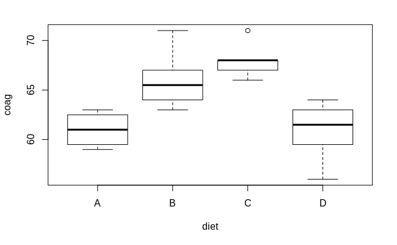

```r
plot( coag ~ diet, data=coagulation)
```

Unpacking this, R will plot “coagulation on diet” (with “coag ~ diet”). This groups according to diet on the horizontal and then boxplots the coagulation times on the vertical.

Looking at the boxplot, it seems natural to ask whether the average coagulation times are independent of diet. This is a problem typically approached with ANOVA (Analysis of Variance). If you type summary(coagulation) you obtain the output seen below.

```r
summary(coagulation)
```

```
      coag       diet
 Min.   :56.00   A:4
 1st Qu.:61.75   B:6
 Median :63.50   C:6
 Mean   :64.00   D:8
 3rd Qu.:67.00
 Max.   :71.00
```

Note that this “bunches up” or aggregates the coagulation data into 24 coagulation times and 24 diet types and tells useful information for each variable individually, rather than associating coagulation time with diet like the last plot. Since coag represents times, it is useful to know the “5 number summary” (i.e. the quartiles) as well as the average, or mean. Diet divides our cases into 4 groups, and you might want to know how many cases are in each group.

If you want to access each variable, you can use the operator “$” as in:

```r
coagulation$diet
```

```
 [1] A A A A B B B B B B C C C C C C D D D D D D D D
Levels: A B C D
```

```r
coagulation$coag
```

```
 [1] 62 60 63 59 63 67 71 64 65 66 68 66 71 67 68 68 56 62 60 61 63 64 63 59
```

Looking at regression:

```r
ourModel = lm(coag~diet-1, coagulation)
summary(ourModel)
```

```
Call:
lm(formula = coag ~ diet - 1, data = coagulation)

Residuals:
   Min     1Q Median     3Q    Max
 -5.00  -1.25   0.00   1.25   5.00

Coefficients:
      Estimate Std. Error t value Pr(>|t|)
dietA  61.0000     1.1832   51.55   <2e-16 ***
dietB  66.0000     0.9661   68.32   <2e-16 ***
dietC  68.0000     0.9661   70.39   <2e-16 ***
dietD  61.0000     0.8367   72.91   <2e-16 ***
---
Signif. codes:  0 ‘***’ 0.001 ‘**’ 0.01 ‘*’ 0.05 ‘.’ 0.1 ‘ ’ 1

Residual standard error: 2.366 on 20 degrees of freedom
Multiple R-squared:  0.9989,    Adjusted R-squared:  0.9986
F-statistic:  4399 on 4 and 20 DF,  p-value: < 2.2e-16
```

For now note, consistent with our box plots, the averages for each of the 4 diets are: 61, 66, 68 and 61 seconds, respectively. (Recall, however, that a box plot shows the median, not the mean).

### Exercise

Load in the data set on poisons, treatments, and rats (effect of toxic agents on rats) with the command:

```r
data(rats, package='faraway')
```

```r
ls()
```

```
 [1] "b0"                 "b1"                 "c02.residuals"
 [4] "co2.linear.model"   "co2.residuals"      "co2.times"
 [7] "co2.values"         "coagulation"        "coefs"
[10] "data.1"             "diffs"              "eqn"
[13] "extra.1"            "extra.2"            "intercept"
[16] "ourModel"           "r2"                 "rats"
[19] "residuals"          "rmse"               "sleep.linear.model"
[22] "slope"              "small.size.dataset" "SSxx"
[25] "SSxy"               "Test_1_scores"      "Test_2_scores"
[28] "worldcup"
```

We can find out about all of these data sets by downloading and reading through http://cran.r-project.org/web/packages/faraway/faraway.pdf

**Description**:  
An experiment was conducted as part of an investigation to combat the effects of certain toxic agents.

```r
colnames(rats)
```

```
[1] "time"   "poison" "treat"
```

- *time* survival time in tens of hours
- *poison* the poison type - a factor with levels I II III
- *treat* the treatment - a factor with levels A B C D

Obtain box plots for survival times by poisons and for survival times on treatments.

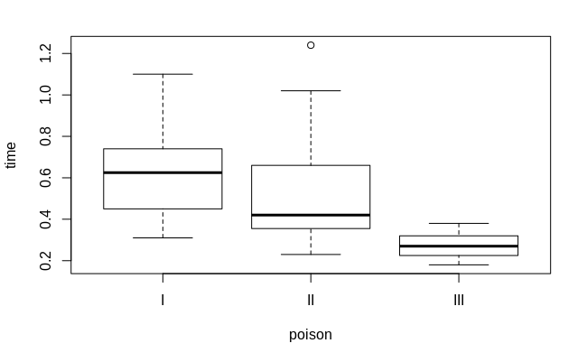

```r
plot(time~poison,data=rats)
```

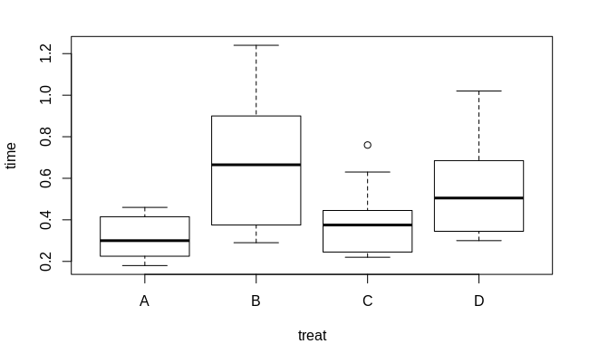

```r
plot(time~treat,data=rats)
```

In the faraway package, we have a data set named “worldcup” giving various R: data on players from the 2010 World Cup. The variable “Time” tells us the time played in minutes by the various players.

After you have installed and loaded the faraway package, find the average time played

```r
data(worldcup, package='faraway')
mean(worldcup$Time)
```

```
[1] 208.8639
```

# Review of Basic Statistics (Descriptive)

**Concatenation and 5-number summary**

Concatenation operator  
data = {35, 8, 10, 23, 42}  
c() for entering dataset in R

```r
data.1=c(35, 8, 10, 23, 42)
```

```r
data.1
```

```
[1] 35  8 10 23 42
```

```r
print(data.1)
```

```
[1] 35  8 10 23 42
```

```r
data.1=c(35, 8, 10,     23,     42)
```

```r
print(data.1)
```

```
[1] 35  8 10 23 42
```

```r
# five-number summary of a dataset
summary(data.1)
```

```
   Min. 1st Qu.  Median    Mean 3rd Qu.    Max.
    8.0    10.0    23.0    23.6    35.0    42.0
```

```r
mean(data.1)
```

```
[1] 23.6
```

```r
median(data.1)
```

```
[1] 23
```

```r
sum(data.1)/5
```

```
[1] 23.6
```

```r
#sample standard deviation
sd(data.1)
```

```
[1] 14.97665
```

**Histograms**

```r
small.size.dataset=c(91,49,76,112,97,42,70, 100, 8, 112, 95, 90, 78, 62, 56, 94, 65, 58, 109, 70, 109, 91, 71, 76, 68, 62, 134, 57, 83, 66)
```

Basic histogram

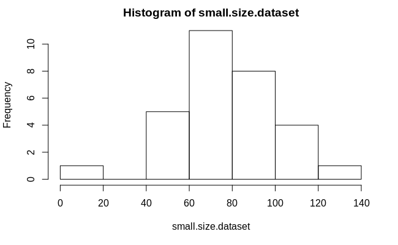

```r
hist(small.size.dataset)
```

Change X axis label

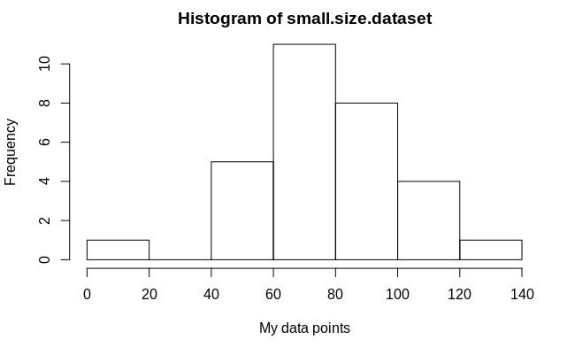

```r
hist(small.size.dataset, xlab='My data points')
```

Change main plot title

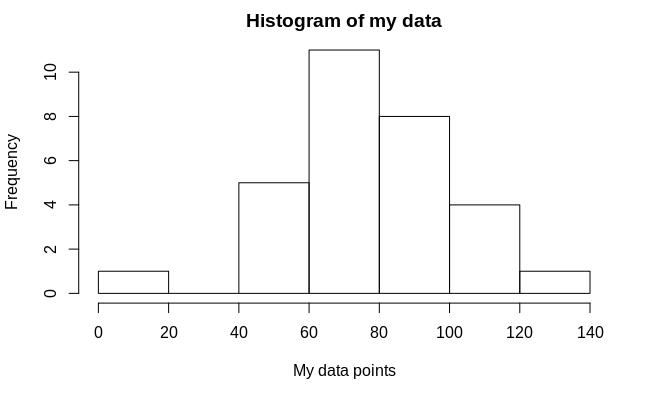

```r
hist(small.size.dataset, xlab='My data points', main='Histogram of my data')
```

Change Y axis to density vs. frequency

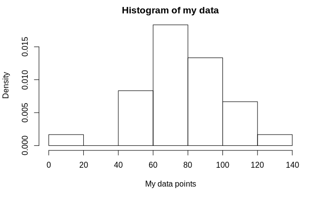

```r
hist(small.size.dataset, xlab='My data points', main='Histogram of my data', freq=F)
```

Change column color

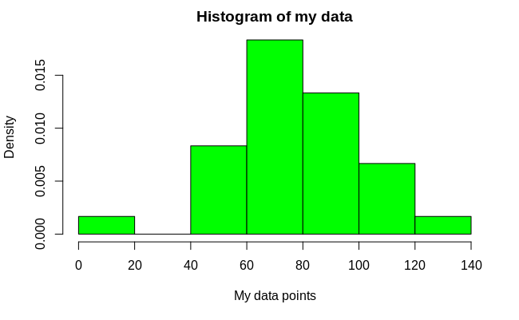

```r
hist(small.size.dataset, xlab='My data points', main='Histogram of my data', freq=F, col='green')
```

Impose smooth density function over histogram

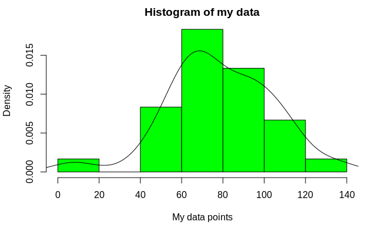

```r
hist(small.size.dataset, xlab='My data points', main='Histogram of my data', freq=F, col='green')
lines(density(small.size.dataset))
```

Change width and color of smooth density function

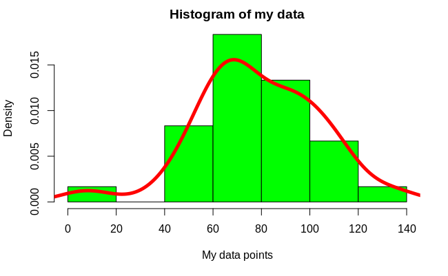

```r
hist(small.size.dataset, xlab='My data points', main='Histogram of my data', freq=F, col='green')
lines(density(small.size.dataset), col='red', lwd=5)
```

Change bin width by changing break points

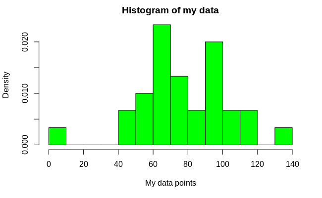

```r
hist(small.size.dataset, xlab='My data points', main='Histogram of my data', freq=F, col='green', breaks=10)
```

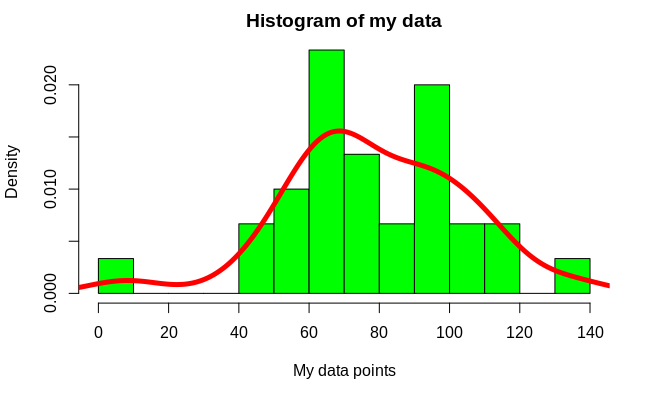

```r
hist(small.size.dataset, xlab='My data points', main='Histogram of my data', freq=F, col='green', breaks=10)
lines(density(small.size.dataset), col='red', lwd=5)
```

**Scatterplots**

For bivariate data  
Similated test scores

```r
set.seed(2016)
```

Generate some data from normal distribution. Let’s say 50 data points with average of 78. And with the standard deviation being 10. Then round to get whole numbers

```r
Test_1_scores=round(rnorm(50, 78, 10))
```

```r
Test_2_scores=round(rnorm(50, 70, 14))
```

```r
Test_1_scores
```

```
 [1]  69  88  77  81  50  75  70  71  82  80  74  75  91  69  94  81  69  88
[19]  71  71  74  71  75  84  80  68  72  91  89  67  68  77  90  63  79  92
[37]  70  70  73  63  77  83  75  72  87  75  65 100  86  61
```

```r
Test_2_scores
```

```
 [1] 68 58 35 54 72 47 93 53 65 64 80 79 62 62 77 89 66 54 64 82 83 75 43 70
[25] 69 81 73 83 70 65 78 77 78 59 49 98 62 79 66 73 89 78 53 80 65 62 72 66
[49] 38 87
```

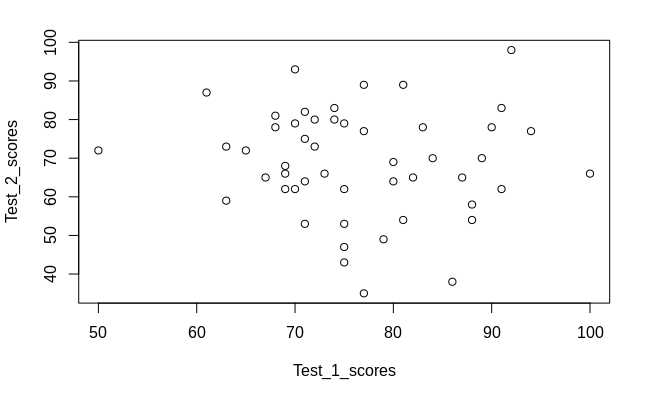

```r
plot(Test_2_scores~Test_1_scores)
```

Add titles and labels

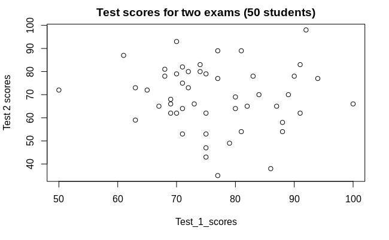

```r
plot(Test_2_scores~Test_1_scores, main='Test scores for two exams (50 students)', xlab='Test_1_scores', ylab='Test 2 scores')
```

Change color

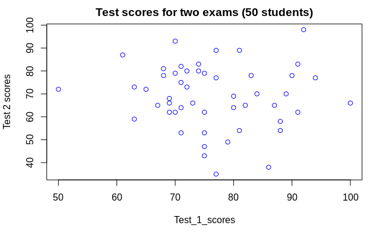

```r
plot(Test_2_scores~Test_1_scores, main='Test scores for two exams (50 students)', xlab='Test_1_scores', ylab='Test 2 scores', col='blue')
```

# Review of Basic Statistics (Inferential)

**Objectives**:  
Perform a simple linear regression with R  
- plot time series data  
- fit a linear model to a set of ordered pairs  
- assess normality of residuals  
- test whether the slope of the fitted line is zero

**When R starts it has a number of packages already loaded. This data set should be available to you just by typing the data set name, at the R command console**

```r
data()
```

We will use the dataset CO2 – atmospheric carbon dioxide concentration during some of the last several decades.

```r
co2
```

```
        Jan    Feb    Mar    Apr    May    Jun    Jul    Aug    Sep    Oct
1959 315.42 316.31 316.50 317.56 318.13 318.00 316.39 314.65 313.68 313.18
1960 316.27 316.81 317.42 318.87 319.87 319.43 318.01 315.74 314.00 313.68
1961 316.73 317.54 318.38 319.31 320.42 319.61 318.42 316.63 314.83 315.16
1962 317.78 318.40 319.53 320.42 320.85 320.45 319.45 317.25 316.11 315.27
1963 318.58 318.92 319.70 321.22 322.08 321.31 319.58 317.61 316.05 315.83
1964 319.41 320.07 320.74 321.40 322.06 321.73 320.27 318.54 316.54 316.71
1965 319.27 320.28 320.73 321.97 322.00 321.71 321.05 318.71 317.66 317.14
1966 320.46 321.43 322.23 323.54 323.91 323.59 322.24 320.20 318.48 317.94
1967 322.17 322.34 322.88 324.25 324.83 323.93 322.38 320.76 319.10 319.24
1968 322.40 322.99 323.73 324.86 325.40 325.20 323.98 321.95 320.18 320.09
1969 323.83 324.26 325.47 326.50 327.21 326.54 325.72 323.50 322.22 321.62
1970 324.89 325.82 326.77 327.97 327.91 327.50 326.18 324.53 322.93 322.90
1971 326.01 326.51 327.01 327.62 328.76 328.40 327.20 325.27 323.20 323.40
1972 326.60 327.47 327.58 329.56 329.90 328.92 327.88 326.16 324.68 325.04
```

[output cut: 65 more lines]

To obtain a description

```r
help(co2)
```

verify that co2 is as time series object

```r
class(co2)
```

```
[1] "ts"
```

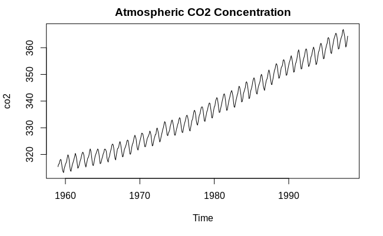

```r
plot(co2, main='Atmospheric CO2 Concentration')
```

CO2 concentration is apparently increasing with time over this period. Also, even though a straight line obviously misses some crucial behavior it isn’t entirely useless in that it can be used to model the **trend** in the data.

We’ll follow the standard notational conventions and make a few minimal assumptions. - The response (i.e. co2 concentration) of the $i^{th}$ observation may be denoted by the random variable $Y_i$.  
- This response depends upon the explanatory variable $x_i$ in a linear way, with some noise added, as  
$Y_i$ = *linear model plus noise* = $(\beta_0 + \beta_1x_i) + \epsilon_i$

The error term $\epsilon_i$ can can arise in a variety of ways:  
measurement error, lack of knowledge of other important influences, etc. When doing a simple regression model, we make the (often reasonable!) assumptions that  
a) the errors are normally distributed $(N(\mu=0, \sigma^=$*constant*$))$ and, on average, zero;  
b) the errors all have the same variance (they are homoscedastic), and  
c) the errors are unrelated to each other (they are independent across observations).

When we find estimates of the slope and intercept using, for example Ordinary Least Squares (OLS), we are not really making any distributional assumptions, just taking a cloud of points and finding numbers that we call a slope and an intercept that minimize a quality term like
$$Q=\Sigma(observed-predicted)^2$$
$Q$ is an aggregate error. The idea behind ordinary least squares (regression) is that we’ll make this aggregate error as small as maethmatically possible.

The observed value is what you have measured, the predicted value is sitting on your straight line. A common notation would be

$Y_i = i^{th}$ *observed response variable*

$\hat{Y}_i = i^{th}$*predicted response variable = slope* $\cdot x_i +$ *intercept*

We can calculate the slope and intercept values follows. First, to get the concentrations and times they were collected available to compute with,

with a bit of knowledge of Calculus…

```r
co2.values = as.numeric(co2)
co2.times = as.numeric( time(co2) )
SSxx = sum( (co2.times - mean(co2.times) ) * (co2.times - mean(co2.times) ) )
SSxy = sum( (co2.values - mean(co2.values) ) * (co2.times - mean(co2.times) ) )
```

```r
slope = SSxy / SSxx
slope
```

```
[1] 1.307497
```

```r
intercept = mean(co2.values) - slope*mean(co2.times)
intercept
```

```
[1] -2249.774
```

Or we can create a linear model a little more simply with the command in R

where lm = the linear model command and co2 can be thought of as the response together with time. In order to extract the time part we’ll use the comman *time*.

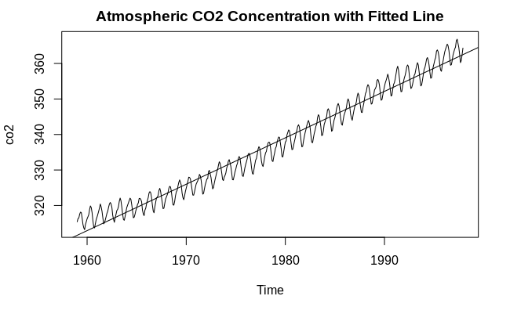

```r
co2.linear.model = lm(co2 ~ time(co2) )

plot(co2, main='Atmospheric CO2 Concentration with Fitted Line')
abline(co2.linear.model )
```

```r
str(co2.linear.model)
```

```
List of 12
 $ coefficients : Named num [1:2] -2249.77 1.31
  ..- attr(*, "names")= chr [1:2] "(Intercept)" "time(co2)"
 $ residuals    : Named num [1:468] 3.81 4.59 4.67 5.62 6.08 ...
  ..- attr(*, "names")= chr [1:468] "1" "2" "3" "4" ...
 $ effects      : Named num [1:468] -7291.58 318.45 4.19 5.14 5.61 ...
  ..- attr(*, "names")= chr [1:468] "(Intercept)" "time(co2)" "" "" ...
 $ rank         : int 2
 $ fitted.values: Named num [1:468] 312 312 312 312 312 ...
  ..- attr(*, "names")= chr [1:468] "1" "2" "3" "4" ...
 $ assign       : int [1:2] 0 1
 $ qr           :List of 5
  ..$ qr   : num [1:468, 1:2] -21.6333 0.0462 0.0462 0.0462 0.0462 ...
  .. ..- attr(*, "dimnames")=List of 2
  .. .. ..$ : chr [1:468] "1" "2" "3" "4" ...
  .. .. ..$ : chr [1:2] "(Intercept)" "time(co2)"
  .. ..- attr(*, "assign")= int [1:2] 0 1
  ..$ qraux: num [1:2] 1.05 1.08
  ..$ pivot: int [1:2] 1 2
  ..$ tol  : num 1e-07
  ..$ rank : int 2
  ..- attr(*, "class")= chr "qr"
 $ df.residual  : int 466
 $ xlevels      : Named list()
 $ call         : language lm(formula = co2 ~ time(co2))
 $ terms        :Classes 'terms', 'formula'  language co2 ~ time(co2)
  .. ..- attr(*, "variables")= language list(co2, time(co2))
  .. ..- attr(*, "factors")= int [1:2, 1] 0 1
  .. .. ..- attr(*, "dimnames")=List of 2
  .. .. .. ..$ : chr [1:2] "co2" "time(co2)"
  .. .. .. ..$ : chr "time(co2)"
  .. ..- attr(*, "term.labels")= chr "time(co2)"
  .. ..- attr(*, "order")= int 1
  .. ..- attr(*, "intercept")= int 1
  .. ..- attr(*, "response")= int 1
  .. ..- attr(*, ".Environment")=<environment: R_GlobalEnv>
  .. ..- attr(*, "predvars")= language list(co2, time(co2))
  .. ..- attr(*, "dataClasses")= Named chr [1:2] "numeric" "numeric"
  .. .. ..- attr(*, "names")= chr [1:2] "co2" "time(co2)"
 $ model        :'data.frame':  468 obs. of  2 variables:
  ..$ co2      : num [1:468] 315 316 316 318 318 ...
  ..$ time(co2): num [1:468] 1959 1959 1959 1959 1959 ...
  ..- attr(*, "terms")=Classes 'terms', 'formula'  language co2 ~ time(co2)
  .. .. ..- attr(*, "variables")= language list(co2, time(co2))
  .. .. ..- attr(*, "factors")= int [1:2, 1] 0 1
  .. .. .. ..- attr(*, "dimnames")=List of 2
  .. .. .. .. ..$ : chr [1:2] "co2" "time(co2)"
  .. .. .. .. ..$ : chr "time(co2)"
  .. .. ..- attr(*, "term.labels")= chr "time(co2)"
  .. .. ..- attr(*, "order")= int 1
  .. .. ..- attr(*, "intercept")= int 1
  .. .. ..- attr(*, "response")= int 1
  .. .. ..- attr(*, ".Environment")=<environment: R_GlobalEnv>
  .. .. ..- attr(*, "predvars")= language list(co2, time(co2))
  .. .. ..- attr(*, "dataClasses")= Named chr [1:2] "numeric" "numeric"
  .. .. .. ..- attr(*, "names")= chr [1:2] "co2" "time(co2)"
 - attr(*, "class")= chr "lm"
```

```r
ls(co2.linear.model)
```

```
 [1] "assign"        "call"          "coefficients"  "df.residual"
 [5] "effects"       "fitted.values" "model"         "qr"
 [9] "rank"          "residuals"     "terms"         "xlevels"
```

```r
coef(co2.linear.model)
```

```
 (Intercept)    time(co2)
-2249.774198     1.307497
```

```r
summary(co2.linear.model)
```

```
Call:
lm(formula = co2 ~ time(co2))

Residuals:
    Min      1Q  Median      3Q     Max
-6.0399 -1.9476 -0.0017  1.9113  6.5149

Coefficients:
              Estimate Std. Error t value Pr(>|t|)
(Intercept) -2.250e+03  2.127e+01  -105.8   <2e-16 ***
time(co2)    1.308e+00  1.075e-02   121.6   <2e-16 ***
---
Signif. codes:  0 ‘***’ 0.001 ‘**’ 0.01 ‘*’ 0.05 ‘.’ 0.1 ‘ ’ 1

Residual standard error: 2.618 on 466 degrees of freedom
Multiple R-squared:  0.9695,    Adjusted R-squared:  0.9694
F-statistic: 1.479e+04 on 1 and 466 DF,  p-value: < 2.2e-16
```

To add rsme, slope, intercept, r^2 to the plot, do the following

```r
## Calculate RMSE and other values
rmse <- round(sqrt(mean(resid(co2.linear.model)^2)), 2)
coefs <- coef(co2.linear.model)
b0 <- round(coefs[1], 2)
b1 <- round(coefs[2],2)
r2 <- round(summary(co2.linear.model)$r.squared, 2)
```

```r
eqn <- bquote(italic(y) == .(b0) + .(b1)*italic(x) * "," ~~
                  r^2 == .(r2) * "," ~~ RMSE == .(rmse))
eqn
```

```
italic(y) == c(`(Intercept)` = -2249.77) + c(`time(co2)` = 1.31) *
    italic(x) * "," ~ ~r^2 == 0.97 * "," ~ ~RMSE == 2.61
```

```r
## Plot the data
plot(co2, main='Atmospheric CO2 Concentration with Fitted Line')
abline(co2.linear.model )
```

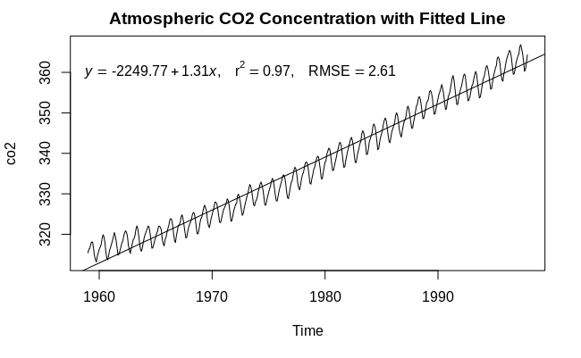

```r
text(1958, 360, eqn, pos = 4)
```

Now take the intercept value with a little bit of caution. We’re not saying that at time zero, the intercept, the carbon dioxide concentration would be ~ -2000. That’s sort of a meaningless thing to say. But given our dataset, the best intercept for that cloud, that scatterplot, really would be -2000. We will not extrapolate back that far. Our model utility would have broken down long before then.

**Assessing the normality of a data set**

For residuals, “interrogate” the linear model with

```r
co2.residuals = resid( co2.linear.model )
```

Do you believe that the residuals are normally distributed? When we have a large data set we can look at a histogram. When a data set is smaller, we can look at a normal probability plot.

Using the par() command to see these plots together, we can see a systematic departure from normality in the tails, along with an obvious structure in the time plot indicating departures from the standard regression assumptions.

```r
par(mfrow=c(1,3))
invisible(( c02.residuals = resid( co2.linear.model ) ) )
hist(co2.residuals, main= "Histogram of CO2 Residuals")
qqnorm(c02.residuals, main= "Normal Probability Plot")
```

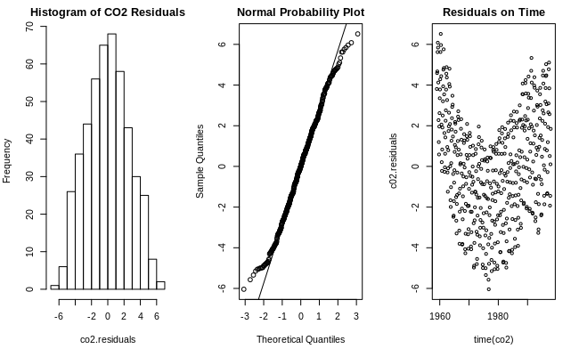

```r
qqline(c02.residuals)
plot(c02.residuals ~ time(co2), main="Residuals on Time")
```

zoom in on the residuals using the “xlim” argument to see the seasonality in the data set. We will address the oscillations in the data later

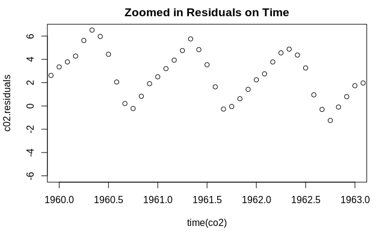

```r
plot(c02.residuals ~ time(co2), xlim=c(1960, 1963), main="Zoomed in Residuals on Time")
```

Zooming in shows oscillatory nature of our data

**Another dataset – sleep**

```r
help(sleep)
```

```r
class(sleep)
```

```
[1] "data.frame"
```

```r
head(sleep)
```

|  | extra | group | ID |
| --- | --- | --- | --- |
| 1 | 0.7 | 1 | 1 |
| 2 | -1.6 | 1 | 2 |
| 3 | -0.2 | 1 | 3 |
| 4 | -1.2 | 1 | 4 |
| 5 | -0.1 | 1 | 5 |
| 6 | 3.4 | 1 | 6 |

Plot your data with the command

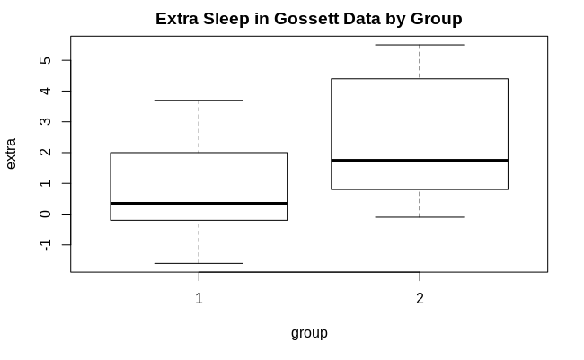

```r
plot(extra~group, data=sleep, main = "Extra Sleep in Gossett Data by Group")
```

In box plot – media extra sleep seems higher in group 2 (from visual inspection)

~~

If you are tired of typing the dollar sign to access a variable, you can “attach” the data frame as

```r
attach(sleep)
```

Now we can access the variables with a little less typing. Disaggregating the extra sleep data into variables specifying those who took drug 1 and those who took drug 2

```r
extra.1=extra[group==1]
extra.2=extra[group==2]
```

An obvious research question would be: Is there a difference in the average response to each of the two drugs?

## T-test

Run your t-test with the command

```r
t.test(extra.1, extra.2, paired=TRUE, alternative="two.sided")
```

```
    Paired t-test

data:  extra.1 and extra.2
t = -4.0621, df = 9, p-value = 0.002833
alternative hypothesis: true difference in means is not equal to 0
95 percent confidence interval:
 -2.4598858 -0.7001142
sample estimates:
mean of the differences
                  -1.58
```

The rather large negative t-value leads us to believe that the visual evidence in the box plot is supported by the statistical approach. The p-value is quite small and our data are significant at the customary 𝛼 = 0.01 level.

$$p < \alpha \Rightarrow reject$$
$$p > \alpha \Rightarrow do.not.reject$$
An interval estimate provides a quality statement and is more interesting than the point estimate of 𝑥̅− 𝑦̅ = −1.58. At the 95% level of confidence we make the traditional statement that, whatever the actual difference in means, our interval estimate is
$$-2.4598858 < \mu_d<-0.7001142$$

for the test to be meaningful, we assume that the population of differences is normally distributed.

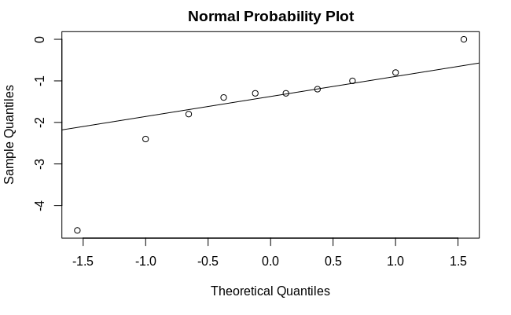

```r
diffs = extra.1-extra.2
qqnorm(diffs, main= "Normal Probability Plot")
qqline(diffs)
```

While this is not a very sensitive test for normality, the hypothesis test itself is robust to departures from normality and, while that outlier is somewhat troubling, we can move forward.

## A Regression Model

Since the data are paired (two different responses by same subject to each drug), it is natural to think of them in an (𝑥, 𝑦) fashion and plot our data in a scatter plot

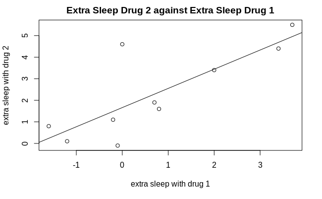

```r
plot(extra.2~extra.1, xlab='extra sleep with drug 1', ylab='extra sleep with drug 2', main='Extra Sleep Drug 2 against Extra Sleep Drug 1')
sleep.linear.model = lm(extra.2 ~ extra.1 )
abline(sleep.linear.model)
```

We have changed our focus from (a) deciding whether the group averages differ to (b) thinking about whether we might say something about a person’s response to the second drug given their response to the first drug. Aside from the one pesky data point (subject 9) it looks like we might be able to do a decent job. So, in this context we might think about performing a regression of 𝑑𝑟𝑢𝑔2 response on 𝑑𝑟𝑢𝑔1 response.

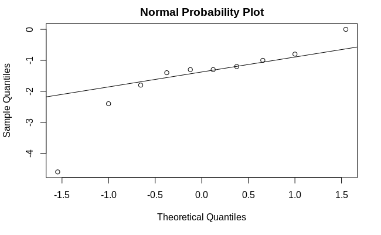

```r
diffs = extra.1-extra.2
qqnorm(diffs, main= "Normal Probability Plot")
qqline(diffs)
```

```r
summary(sleep.linear.model)
```

```
Call:
lm(formula = extra.2 ~ extra.1)

Residuals:
    Min      1Q  Median      3Q     Max
-1.6735 -0.4673 -0.3365  0.3979  2.9375

Coefficients:
            Estimate Std. Error t value Pr(>|t|)
(Intercept)   1.6625     0.4452   3.734  0.00575 **
extra.1       0.8899     0.2399   3.709  0.00596 **
---
Signif. codes:  0 ‘***’ 0.001 ‘**’ 0.01 ‘*’ 0.05 ‘.’ 0.1 ‘ ’ 1

Residual standard error: 1.288 on 8 degrees of freedom
Multiple R-squared:  0.6323,    Adjusted R-squared:  0.5863
F-statistic: 13.76 on 1 and 8 DF,  p-value: 0.005965
```

Our model is then

$$extra.2 = 0.8899 \cdot extra.1 + 1.6625$$
On the standard test of whether the slope is zero, our p-value is 0.00596 < .01 and so we believe the slope is not zero

What is the residual associated with the 3rd data point?

```r
residuals = resid(sleep.linear.model)
residuals[3]
```

```
         3
-0.3845478
```

## Correlation

One of the most important tools in time series analysis is the **Auto-Correlation Function**, or **ACF**.

Below we overview required concepts by looking at a very popular way to measure the strength of linear association between two variables, the correlation coefficient.

Girth, Height and Volume for Black Cherry Trees

This data set provides measurements of the girth, height and volume of timber in 31 felled black cherry trees. Note that girth is the diameter of the tree (in inches) measured at 4 ft 6 in above the ground.

```r
help(trees)
```

```r
class(trees)
```

```
[1] "data.frame"
```

```r
head(trees)
```

|  | Girth | Height | Volume |
| --- | --- | --- | --- |
| 1 | 8.3 | 70 | 10.3 |
| 2 | 8.6 | 65 | 10.3 |
| 3 | 8.8 | 63 | 10.2 |
| 4 | 10.5 | 72 | 16.4 |
| 5 | 10.7 | 81 | 18.8 |
| 6 | 10.8 | 83 | 19.7 |

It’s always natural to take a look at our data and we’ll do so with a “pairs” plot.

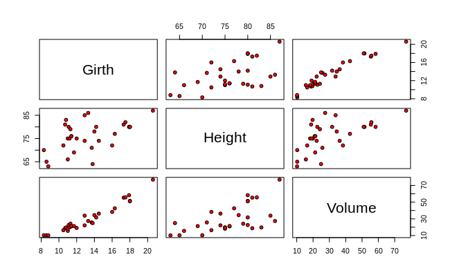

```r
pairs(trees, pch = 21, bg = c("red"))
```

It appears that our variables are all positively correlated, as we’d expect. The linear relationship between Girth and Volume seems especially strong.

Covariance measures how much two random variables vary together. But it does not tell exactly how strong that relationship is… that’s where correlation coefficients come in….

```r
cov(trees)
```

```
           Girth   Height    Volume
Girth   9.847914 10.38333  49.88812
Height 10.383333 40.60000  62.66000
Volume 49.888118 62.66000 270.20280
```

….The problem with covariance can be fixed by dividing the covariance by the standard deviation to get the correlation coefficient.

Correlation coefficient (covariance in standard units)

```r
cor(trees)
```

```
           Girth    Height    Volume
Girth  1.0000000 0.5192801 0.9671194
Height 0.5192801 1.0000000 0.5982497
Volume 0.9671194 0.5982497 1.0000000
```

Advantages of the Correlation Coefficient

The Correlation Coefficient has several advantages over covariance for determining strengths of relationships:

- Covariance can take on practically any number while a correlation is limited: -1 to +1.
- Because of it’s numerical limitations, correlation is more useful for determining how strong the relationship is between the two variables.
- Correlation does not have units. Covariance always has units.
- Correlation isn’t affected by changes in the center (i.e. mean) or scale of the variables.

#### HINTS: